# Cx4073 : Assignment 3

Arkar Min

U1721052K

### Finding Market Segments in Online Retail

```r
retailData <- read.csv("assign3_RetailData.csv", header = TRUE)
str(retailData)
```

```
## 'data.frame':    541909 obs. of  8 variables:
##  $ InvoiceNo  : Factor w/ 25900 levels "536365","536366",..: 1 1 1 1 1 1 1 2 2 3 ...
##  $ StockCode  : Factor w/ 4070 levels "10002","10080",..: 3538 2795 3045 2986 2985 1663 801 1548 1547 3306 ...
##  $ Description: Factor w/ 4224 levels ""," 4 PURPLE FLOCK DINNER CANDLES",..: 4027 4035 932 1959 2980 3235 1573 1698 1695 259 ...
##  $ Quantity   : int  6 6 8 6 6 2 6 6 6 32 ...
##  $ InvoiceDate: Factor w/ 23260 levels "1/11/11 10:01",..: 198 198 198 198 198 198 198 199 199 200 ...
##  $ UnitPrice  : num  2.55 3.39 2.75 3.39 3.39 7.65 4.25 1.85 1.85 1.69 ...
##  $ CustomerID : int  17850 17850 17850 17850 17850 17850 17850 17850 17850 13047 ...
##  $ Country    : Factor w/ 38 levels "Australia","Austria",..: 36 36 36 36 36 36 36 36 36 36 ...
```

The following table summarizes the variables in the dataset. Note the type carefully, and convert if required.

| Variable | Description | Remarks |
| --- | --- | --- |
| InvoiceNo | The serial number on the Invoice | May be different for same product and same customer. |
| StockCode | Product (item) code in the Store | Uniquely assigned to every distinct Product (item). |
| Description | Product (item) name in the Store | May be different for the same StockCode. Do check. |
| Quantity | Product Quantity in the Transaction | Will of course change with different transactions. |
| InvoiceDate | Date-Time of the Transaction | Can you use this too? Try, but it is strictly optional. |
| UnitPrice | Product Price per Unit (in Dollars) | Should be the same for the same Product. Do check. |
| CustomerID | Customer code in the Store | Same customer may make various purchases. Check carefully. |
| Country | Country of Residence of Customer | Should be the same for each individual Customer. |

Hint : Think of creating a Customer-Product matrix before you start your market segmentation. First step is deciding the elements in the matrix, and the second step if to choose the notion of distance that whould be appropriate for this case. See if you can effectively use the variables like `Quantity`, `UnitPrice`, `InvoiceDate` and `Country` in this market segmentation. Don’t forget to interpret the market segments that you get!

## Basic Data Exploration

```r
dim(retailData)
```

```
## [1] 541909      8
```

```r
names(retailData)
```

```
## [1] "InvoiceNo"   "StockCode"   "Description" "Quantity"    "InvoiceDate"
## [6] "UnitPrice"   "CustomerID"  "Country"
```

There are 541,909 records with 8 columns in the data. Exploration will be started by looking at the summary of all data and first 5 rows of data and last 5 rows of data.

```r
summary(retailData)
```

```
##    InvoiceNo        StockCode
##  573585 :  1114   85123A :  2313
##  581219 :   749   22423  :  2203
##  581492 :   731   85099B :  2159
##  580729 :   721   47566  :  1727
##  558475 :   705   20725  :  1639
##  579777 :   687   84879  :  1502
##  (Other):537202   (Other):530366
##                              Description        Quantity
##  WHITE HANGING HEART T-LIGHT HOLDER:  2369   Min.   :-80995.00
##  REGENCY CAKESTAND 3 TIER          :  2200   1st Qu.:     1.00
##  JUMBO BAG RED RETROSPOT           :  2159   Median :     3.00
##  PARTY BUNTING                     :  1727   Mean   :     9.55
##  LUNCH BAG RED RETROSPOT           :  1638   3rd Qu.:    10.00
##  ASSORTED COLOUR BIRD ORNAMENT     :  1501   Max.   : 80995.00
##  (Other)                           :530315
##          InvoiceDate       UnitPrice           CustomerID
##  31/10/11 14:41:  1114   Min.   :-11062.06   Min.   :12346
##  8/12/11 9:28  :   749   1st Qu.:     1.25   1st Qu.:13953
##  9/12/11 10:03 :   731   Median :     2.08   Median :15152
##  5/12/11 17:24 :   721   Mean   :     4.61   Mean   :15288
##  29/6/11 15:58 :   705   3rd Qu.:     4.13   3rd Qu.:16791
##  30/11/11 15:13:   687   Max.   : 38970.00   Max.   :18287
##  (Other)       :537202                       NA's   :135080
##            Country
##  United Kingdom:495478
##  Germany       :  9495
##  France        :  8557
##  EIRE          :  8196
##  Spain         :  2533
##  Netherlands   :  2371
##  (Other)       : 15279
```

```r
head(retailData)
```

```
##   InvoiceNo StockCode                         Description Quantity
## 1    536365    85123A  WHITE HANGING HEART T-LIGHT HOLDER        6
## 2    536365     71053                 WHITE METAL LANTERN        6
## 3    536365    84406B      CREAM CUPID HEARTS COAT HANGER        8
## 4    536365    84029G KNITTED UNION FLAG HOT WATER BOTTLE        6
## 5    536365    84029E      RED WOOLLY HOTTIE WHITE HEART.        6
## 6    536365     22752        SET 7 BABUSHKA NESTING BOXES        2
##    InvoiceDate UnitPrice CustomerID        Country
## 1 1/12/10 8:26      2.55      17850 United Kingdom
## 2 1/12/10 8:26      3.39      17850 United Kingdom
## 3 1/12/10 8:26      2.75      17850 United Kingdom
## 4 1/12/10 8:26      3.39      17850 United Kingdom
## 5 1/12/10 8:26      3.39      17850 United Kingdom
## 6 1/12/10 8:26      7.65      17850 United Kingdom
```

```r
tail(retailData)
```

```
##        InvoiceNo StockCode                     Description Quantity
## 541904    581587     23256     CHILDRENS CUTLERY SPACEBOY         4
## 541905    581587     22613     PACK OF 20 SPACEBOY NAPKINS       12
## 541906    581587     22899    CHILDREN'S APRON DOLLY GIRL         6
## 541907    581587     23254   CHILDRENS CUTLERY DOLLY GIRL         4
## 541908    581587     23255 CHILDRENS CUTLERY CIRCUS PARADE        4
## 541909    581587     22138   BAKING SET 9 PIECE RETROSPOT         3
##          InvoiceDate UnitPrice CustomerID Country
## 541904 9/12/11 12:50      4.15      12680  France
## 541905 9/12/11 12:50      0.85      12680  France
## 541906 9/12/11 12:50      2.10      12680  France
## 541907 9/12/11 12:50      4.15      12680  France
## 541908 9/12/11 12:50      4.15      12680  France
## 541909 9/12/11 12:50      4.95      12680  France
```

InvoiceNo describes the unique transaction that the customer made. So, invoice number “573585” appears more than 1000 times means that one customer buy more than 1000 products in one transaction.

```r
summary(retailData[which(retailData$InvoiceNo == 573585, arr.ind=TRUE),])
```

```
##    InvoiceNo      StockCode                                 Description
##  573585 :1114   22581  :   2   CHARLIE LOLA BLUE HOT WATER BOTTLE :   2
##  536365 :   0   22998  :   2   CHARLIE+LOLA RED HOT WATER BOTTLE  :   2
##  536366 :   0   23322  :   2   LARGE WHITE HEART OF WICKER        :   2
##  536367 :   0   23539  :   2   TRAVEL CARD WALLET KEEP CALM       :   2
##  536368 :   0   11001  :   1   WALL ART LOVES' SECRET             :   2
##  536369 :   0   15036  :   1   WOOD STOCKING CHRISTMAS SCANDISPOT :   2
##  (Other):   0   (Other):1104   (Other)                            :1102
##     Quantity               InvoiceDate     UnitPrice          CustomerID
##  Min.   :  1.000   31/10/11 14:41:1114   Min.   :   0.420   Min.   : NA
##  1st Qu.:  1.000   1/11/11 10:01 :   0   1st Qu.:   1.630   1st Qu.: NA
##  Median :  2.000   1/11/11 10:02 :   0   Median :   3.290   Median : NA
##  Mean   :  4.666   1/11/11 10:04 :   0   Mean   :   6.312   Mean   :NaN
##  3rd Qu.:  5.000   1/11/11 10:12 :   0   3rd Qu.:   5.790   3rd Qu.: NA
##  Max.   :200.000   1/11/11 10:13 :   0   Max.   :2019.050   Max.   : NA
##                    (Other)       :   0                      NA's   :1114
##            Country
##  United Kingdom:1114
##  Australia     :   0
##  Austria       :   0
##  Bahrain       :   0
##  Belgium       :   0
##  Brazil        :   0
##  (Other)       :   0
```

Interestingly, transactions are made by customer whose customerID is NA. So, there are NA values in customerID.

```r
nlevels(retailData$StockCode)
```

```
## [1] 4070
```

```r
nlevels(retailData$Description)
```

```
## [1] 4224
```

There are total unique 4070 stock codes and 4224 descriptions. So, there can be cases that more than one description is used for the same stock code.

```r
x <- retailData$Description[which(retailData$StockCode == '84879', arr.ind = TRUE)]
summary(x)
```

```
##       ASSORTED COLOUR BIRD ORNAMENT                             damaged
##                                1501                                   1
##                                           4 PURPLE FLOCK DINNER CANDLES
##                                   0                                   0
##       50'S CHRISTMAS GIFT BAG LARGE                   DOLLY GIRL BEAKER
##                                   0                                   0
##         I LOVE LONDON MINI BACKPACK         I LOVE LONDON MINI RUCKSACK
##                                   0                                   0
##             NINE DRAWER OFFICE TIDY          OVAL WALL MIRROR DIAMANTE
##                                   0                                   0
##             RED SPOT GIFT BAG LARGE     SET 2 TEA TOWELS I LOVE LONDON
##                                   0                                   0
##              SPACEBOY BABY GIFT SET            TOADSTOOL BEDSIDE LIGHT
##                                   0                                   0
##                   TRELLIS COAT RACK                                   ?
```

[output cut: 85 more lines]

According to above example, they do have different description for same product. Another interesting fact is like you can see some weired descriptions like “?”, “???damages”, “?lost” and so on.

```r
sum(retailData$Quantity <= 0)
```

```
## [1] 10624
```

Min and Max quantity value is too large. There are 10,624 values which are less than zero in the data. It does not make sense to have negative value or zero value in the quantity in transaction data.

InvoiceDate will not be used. So, there will be no exploration.

```r
sum(retailData$UnitPrice <= 0)
```

```
## [1] 2517
```

There are 2517 objects with unit price less than or equal to zero. Once again, it does not make sense have those kind of values in unit price.

```r
which(retailData$UnitPrice < 0, arr.ind=TRUE)
```

```
## [1] 299984 299985
```

```r
retailData[299984,]
```

```
##        InvoiceNo StockCode     Description Quantity   InvoiceDate
## 299984   A563186         B Adjust bad debt        1 12/8/11 14:51
##        UnitPrice CustomerID        Country
## 299984 -11062.06         NA United Kingdom
```

```r
which(retailData$UnitPrice == 38970, arr.ind=TRUE)
```

```
## [1] 222682
```

```r
retailData[222682,]
```

```
##        InvoiceNo StockCode Description Quantity   InvoiceDate UnitPrice
## 222682   C556445         M      Manual       -1 10/6/11 15:31     38970
##        CustomerID        Country
## 222682      15098 United Kingdom
```

Data which has highest value and lowest values are checked. Both are very weired data. Likely to be error data.

```r
sum(is.na(retailData$CustomerID)) #135080
```

```
## [1] 135080
```

```r
summary(retailData$InvoiceNo[which(retailData$CustomerID == 17850, arr.ind = TRUE)])
```

```
##  536750  536752  536396  536406  536685  536690  536790  536373  536375
##      19      19      18      17      17      17      17      16      16
##  536609  536628  536630  536612 C543611  536787  536600  536602  536365
##      16      16      16      15      15      13      12      12       7
##  536366  536372  536377  536399  536407  536601  536603  536610  536614
##       2       2       2       2       2       2       2       2       2
##  536629  536631  536688  536693  536751  536753  536789  536791  536367
##       2       2       2       2       2       2       2       2       0
##  536368  536369  536370  536371  536374  536376  536378  536380  536381
##       0       0       0       0       0       0       0       0       0
##  536382  536384  536385  536386  536387  536388  536389  536390  536392
##       0       0       0       0       0       0       0       0       0
##  536393  536394  536395  536397  536398  536400  536401  536402  536403
##       0       0       0       0       0       0       0       0       0
##  536404  536405  536408  536409  536412  536414  536415  536416  536420
##       0       0       0       0       0       0       0       0       0
##  536423  536425  536437  536446  536460  536463  536464  536466  536477
##       0       0       0       0       0       0       0       0       0
##  536488  536500  536502  536508  536514  536520  536521  536522  536523
##       0       0       0       0       0       0       0       0       0
##  536524  536525  536526  536527  536528  536529  536530  536531  536532
##       0       0       0       0       0       0       0       0       0
## (Other)
##       0
```

There are 135080 NA values in customer ID. Customer ID should not be continuous variable. It should be categorical variable since each customer has unique number. Same customer can make a lot of purchases. For example, customer ID 17850 makes 35 transactions in the store.

```r
summary(retailData$Country)
```

```
##            Australia              Austria              Bahrain
##                 1259                  401                   19
##              Belgium               Brazil               Canada
##                 2069                   32                  151
##      Channel Islands               Cyprus       Czech Republic
##                  758                  622                   30
##              Denmark                 EIRE   European Community
##                  389                 8196                   61
##              Finland               France              Germany
##                  695                 8557                 9495
##               Greece            Hong Kong              Iceland
##                  146                  288                  182
##               Israel                Italy                Japan
##                  297                  803                  358
##              Lebanon            Lithuania                Malta
##                   45                   35                  127
##          Netherlands               Norway               Poland
##                 2371                 1086                  341
##             Portugal                  RSA         Saudi Arabia
##                 1519                   58                   10
##            Singapore                Spain               Sweden
##                  229                 2533                  462
##          Switzerland United Arab Emirates       United Kingdom
##                 2002                   68               495478
##          Unspecified                  USA
##                  446                  291
```

There are 38 different countries. Most of the customers are from United Kingdom. Second and Third are from neighbour countries of UK, which is Germany and France.

Let see whether the same product can have different price or not.

```r
head(retailData$UnitPrice[which(retailData$StockCode == '85123A', arr.ind = TRUE)],30)
```

```
##  [1] 2.55 2.55 2.55 2.55 2.55 2.55 2.95 2.55 2.95 2.95 2.95 5.91 2.55 2.55
## [15] 2.95 5.91 2.95 2.55 2.55 2.95 2.55 2.55 2.55 2.55 2.55 2.55 2.95 2.55
## [29] 2.55 2.95
```

```r
retailData[1,]
```

```
##   InvoiceNo StockCode                        Description Quantity
## 1    536365    85123A WHITE HANGING HEART T-LIGHT HOLDER        6
##    InvoiceDate UnitPrice CustomerID        Country
## 1 1/12/10 8:26      2.55      17850 United Kingdom
```

```r
retailData[365,]
```

```
##     InvoiceNo StockCode                        Description Quantity
## 365    536401    85123A WHITE HANGING HEART T-LIGHT HOLDER        4
##       InvoiceDate UnitPrice CustomerID        Country
## 365 1/12/10 11:21      2.95      15862 United Kingdom
```

```r
retailData[10770,]
```

```
##       InvoiceNo StockCode                        Description Quantity
## 10770    537237    85123A WHITE HANGING HEART T-LIGHT HOLDER        2
##        InvoiceDate UnitPrice CustomerID        Country
## 10770 6/12/10 9:58      5.91         NA United Kingdom
```

```r
head(retailData$UnitPrice[which(retailData$StockCode == '22423', arr.ind = TRUE)],30)
```

```
##  [1] 10.95 12.75 12.75 12.75 12.75 12.75 12.75 12.72 12.75 12.72 12.75
## [12] 12.75 12.75 12.75 12.75 12.75 12.75 10.95 10.95 12.75 12.75 12.75
## [23] 25.49 12.72 12.75 12.75 10.95 12.75 10.95 25.49
```

```r
retailData[881,]
```

```
##     InvoiceNo StockCode              Description Quantity   InvoiceDate
## 881    536477     22423 REGENCY CAKESTAND 3 TIER       16 1/12/10 12:27
##     UnitPrice CustomerID        Country
## 881     10.95      16210 United Kingdom
```

```r
retailData[937,]
```

```
##     InvoiceNo StockCode              Description Quantity   InvoiceDate
## 937    536502     22423 REGENCY CAKESTAND 3 TIER        2 1/12/10 12:36
##     UnitPrice CustomerID        Country
## 937     12.75      16552 United Kingdom
```

```r
retailData[5864,]
```

```
##      InvoiceNo StockCode              Description Quantity   InvoiceDate
## 5864    536876     22423 REGENCY CAKESTAND 3 TIER       40 3/12/10 11:36
##      UnitPrice CustomerID        Country
## 5864     12.72         NA United Kingdom
```

```r
retailData[6902,]
```

```
##      InvoiceNo StockCode              Description Quantity   InvoiceDate
## 6902    536982     22423 REGENCY CAKESTAND 3 TIER       33 3/12/10 14:27
##      UnitPrice CustomerID        Country
## 6902     25.49         NA United Kingdom
```

The answer is yes. They can have different price. Cannot figure out exactly how pricing works. Even though, customers from the same country bought the same item, they have to pay different price.

This is the end of data exploration.

## Data Cleansing

Firstly, CustomerID will be changed into categorical data.

```r
retailData$CustomerID <- as.factor(retailData$CustomerID)
```

According to Initial Data Analysis, those rows with CustomerID NA are assumed to be errors. So, all the rows which has NA values inside will be removed.

```r
retailData <- na.omit(retailData)
```

Since it does not make sense to have zero or negative value in quantity, those values will be removed.

```r
retailData <- retailData[!(retailData$Quantity <= 0),]
```

And also, it does not make sense to have zero or negative value in price, so those values will be removed.

```r
retailData <- retailData[!(retailData$UnitPrice <= 0),]
```

```r
retailData <- retailData[!(retailData$Quantity > 12),]
```

This is the summary of data after Data Cleansing.

```r
summary(retailData)
```

```
##    InvoiceNo        StockCode
##  576339 :   509   85123A :  1599
##  579196 :   509   22423  :  1411
##  580727 :   499   47566  :  1217
##  573576 :   428   85099B :  1138
##  578270 :   416   POST   :  1096
##  567656 :   410   20725  :  1091
##  (Other):329189   (Other):324408
##                              Description        Quantity
##  WHITE HANGING HEART T-LIGHT HOLDER:  1593   Min.   : 1.000
##  REGENCY CAKESTAND 3 TIER          :  1411   1st Qu.: 2.000
##  PARTY BUNTING                     :  1217   Median : 4.000
##  JUMBO BAG RED RETROSPOT           :  1138   Mean   : 5.165
##  POSTAGE                           :  1096   3rd Qu.: 8.000
##  LUNCH BAG RED RETROSPOT           :  1091   Max.   :12.000
##  (Other)                           :324414
##          InvoiceDate       UnitPrice          CustomerID
##  14/11/11 15:27:   509   Min.   :   0.001   17841  :  7635
##  28/11/11 15:54:   509   1st Qu.:   1.250   14096  :  4951
##  5/12/11 17:17 :   499   Median :   2.080   14911  :  4438
##  31/10/11 14:09:   428   Mean   :   3.459   12748  :  4258
##  23/11/11 13:39:   417   3rd Qu.:   3.750   14606  :  2650
##  21/9/11 14:40 :   410   Max.   :8142.750   15311  :  1928
##  (Other)       :329188                      (Other):306100
##            Country
##  United Kingdom:300260
##  Germany       :  7071
##  France        :  6561
##  EIRE          :  5381
##  Spain         :  2103
##  Belgium       :  1679
##  (Other)       :  8905
```

## Market Segmentation

Firstly, market segmentation will be done on the customers from two countries, Germany and France. This is because they have second and third most customer-based after UK.

Then, market segmentation will be done the whole sale data.

## Segmentation on Customers from France

Segmentation will be done on France first.

```r
France <- subset(retailData, Country == "France")
summary(France)
```

```
##    InvoiceNo      StockCode                                 Description
##  570672 : 206   POST   : 300   POSTAGE                            : 300
##  578541 : 115   22554  :  55   PLASTERS IN TIN WOODLAND ANIMALS   :  55
##  569332 :  77   20750  :  54   RED RETROSPOT MINI CASES           :  54
##  569568 :  74   22326  :  54   ROUND SNACK BOXES SET OF4 WOODLAND :  54
##  576927 :  69   22352  :  53   LUNCH BOX WITH CUTLERY RETROSPOT   :  53
##  539050 :  67   22556  :  49   PLASTERS IN TIN CIRCUS PARADE      :  49
##  (Other):5953   (Other):5996   (Other)                            :5996
##     Quantity              InvoiceDate     UnitPrice          CustomerID
##  Min.   : 1.000   11/10/11 14:52: 206   Min.   :   0.120   12681  : 517
##  1st Qu.: 4.000   24/11/11 15:01: 115   1st Qu.:   1.250   12682  : 471
##  Median : 8.000   3/10/11 13:46 :  77   Median :   2.080   12567  : 390
##  Mean   : 7.559   5/10/11 9:57  :  74   Mean   :   5.285   12637  : 370
##  3rd Qu.:12.000   17/11/11 11:02:  69   3rd Qu.:   4.150   12683  : 247
##  Max.   :12.000   15/12/10 16:21:  67   Max.   :4161.060   12700  : 224
##                   (Other)       :5953                      (Other):4342
##       Country
##  France   :6561
##  Australia:   0
##  Austria  :   0
##  Bahrain  :   0
##  Belgium  :   0
##  Brazil   :   0
##  (Other)  :   0
```

We have 6561 total sale records for France. Customer-Product matrix for France will be created first. Row will be the customerID, column will be StockCode and Quantiy will be the value of the matrix.

```r
Francematrix <- xtabs(Quantity ~ CustomerID + StockCode, data = France)
Francematrix <- Francematrix[rowSums(Francematrix)>0,]
Francematrix <- Francematrix[,colSums(Francematrix) > 0]
library(Matrix)
Francematrix <- Matrix(Francematrix, sparse = TRUE)
str(Francematrix)
```

```
## Formal class 'dgCMatrix' [package "Matrix"] with 6 slots
##   ..@ i       : int [1:4618] 38 55 56 24 3 20 58 20 17 18 ...
##   ..@ p       : int [1:1330] 0 3 4 5 6 7 8 15 20 22 ...
##   ..@ Dim     : int [1:2] 86 1329
##   ..@ Dimnames:List of 2
##   .. ..$ CustomerID: chr [1:86] "12413" "12437" "12441" "12488" ...
##   .. ..$ StockCode : chr [1:1329] "10002" "10120" "10135" "15036" ...
##   ..@ x       : num [1:4618] 12 12 24 10 10 24 10 6 9 3 ...
##   ..@ factors : list()
```

A very large matrix is created with 4372 rows and 4070 columns. So, all the rows and columns which has sum of zero are removed since they don’t of any information. This reduces the dimension of the matrix to become 86x1329. This can be interpreted as 86 unique customers from France bought products from 1329 categories.

K-means will be used as an algorithm for clustering. Distance will be Euclidean distance since we are comparing the distance between various quantity vector. Based on the within varience and between varience, the number of clusters to be done is decided.

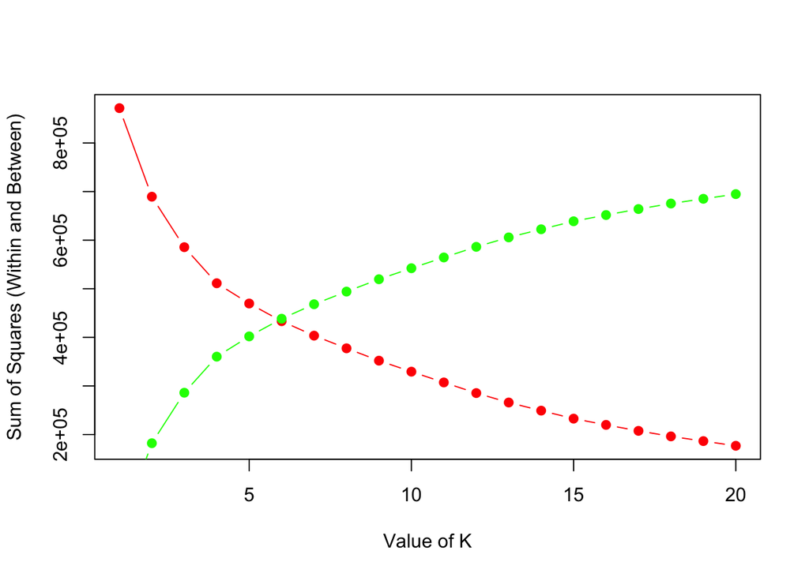

```r
kMin <- 1
kMax <- 20
withinSS <- double(kMax - kMin + 1)
betweenSS <- double(kMax - kMin + 1)

for (K in kMin:kMax) {
  kMeansFit <- kmeans(Francematrix, centers = K, nstart = 20)
  withinSS[K] <- sum(kMeansFit$withinss)
  betweenSS[K] <- kMeansFit$betweenss
}
plot(kMin:kMax, withinSS, pch=19, type="b", col="red",
     xlab = "Value of K", ylab = "Sum of Squares (Within and Between)")
points(kMin:kMax, betweenSS, pch=19, type="b", col="green")
```

Based on the plot, it seems like having 3 clusters has a good trade-off between within varience and between varience.

```r
set.seed(20)
K <- 3
kMeansFit <- kmeans(Francematrix, centers = K, nstart = 20)
kMeansFit$withinss
```

```
## [1]  74236.0 213362.7 297989.5
```

Let analyse each cluster.

```r
clustLabels <- kMeansFit$cluster
kMeansClust1 = France[clustLabels == 1,]
kMeansClust2 = France[clustLabels == 2,]
kMeansClust3 = France[clustLabels == 3,]
```

For each level, those levels which has zero value will be dropped to get the easier analysis of unique customers.

```r
kMeansClust1 <- droplevels(kMeansClust1)
kMeansClust2 <- droplevels(kMeansClust2)
kMeansClust3 <- droplevels(kMeansClust3)
```

### Clusters Analysis

```r
summary(kMeansClust1)
```

```
##    InvoiceNo     StockCode                         Description
##  570672 :  6   POST   :  5   POSTAGE                     :  5
##  578541 :  4   21086  :  3   BLUE POLKADOT CUP           :  3
##  537065 :  2   21240  :  3   SET/6 RED SPOTTY PAPER CUPS :  3
##  537897 :  2   21746  :  3   SMALL RED RETROSPOT WINDMILL:  3
##  539050 :  2   20685  :  2   ALARM CLOCK BAKELIKE PINK   :  2
##  539607 :  2   21080  :  2   CHILDREN'S CIRCUS PARADE MUG:  2
##  (Other):134   (Other):134   (Other)                     :134
##     Quantity              InvoiceDate    UnitPrice        CustomerID
##  Min.   : 1.000   11/10/11 14:52:  6   Min.   : 0.390   12681  :20
##  1st Qu.: 4.000   24/11/11 15:01:  4   1st Qu.: 1.150   12567  :12
##  Median : 6.000   1/11/11 13:56 :  2   Median : 2.080   12682  :11
##  Mean   : 7.309   1/4/11 9:19   :  2   Mean   : 3.679   12637  :10
##  3rd Qu.:12.000   10/1/11 13:22 :  2   3rd Qu.: 4.150   12536  : 6
##  Max.   :12.000   10/11/11 10:53:  2   Max.   :18.000   12700  : 6
##                   (Other)       :134                    (Other):87
##    Country
##  France:152
##
##
##
##
##
##
```

```r
nlevels(kMeansClust1$CustomerID)
```

```
## [1] 41
```

```r
nlevels(kMeansClust1$StockCode)
```

```
## [1] 131
```

So, there are 41 unique customers which bought 131 unique products in this cluster. Total 152 records are inside the cluster. This is smallest cluster.

```r
summary(kMeansClust2)
```

```
##    InvoiceNo     StockCode                           Description
##  570672 : 22   POST   : 21   POSTAGE                       : 21
##  578541 : 12   20750  :  9   RED RETROSPOT MINI CASES      :  9
##  541631 :  8   21731  :  9   RED TOADSTOOL LED NIGHT LIGHT :  9
##  565930 :  8   22629  :  8   SPACEBOY LUNCH BOX            :  8
##  576927 :  8   21936  :  7   CHILDRENS CUTLERY SPACEBOY    :  7
##  547892 :  7   22423  :  7   PLASTERS IN TIN CIRCUS PARADE :  7
##  (Other):623   (Other):627   (Other)                       :627
##     Quantity              InvoiceDate    UnitPrice        CustomerID
##  Min.   : 1.000   11/10/11 14:52: 22   Min.   : 0.290   12682  : 61
##  1st Qu.: 4.000   24/11/11 15:01: 12   1st Qu.: 1.450   12681  : 52
##  Median : 8.000   17/11/11 11:02:  8   Median : 2.080   12567  : 42
##  Mean   : 7.584   8/9/11 10:32  :  8   Mean   : 3.525   12637  : 36
##  3rd Qu.:12.000   28/3/11 10:15 :  7   3rd Qu.: 4.150   12683  : 24
##  Max.   :12.000   4/11/11 13:15 :  7   Max.   :18.000   12536  : 22
##                   (Other)       :624                    (Other):451
##    Country
##  France:688
##
##
##
##
##
##
```

```r
nlevels(kMeansClust2$CustomerID)
```

```
## [1] 80
```

```r
nlevels(kMeansClust2$StockCode)
```

```
## [1] 413
```

So, there are 80 unique customers which bought 413 unique products in this cluster. Total 688 records are inside the cluster.

```r
summary(kMeansClust3)
```

```
##    InvoiceNo      StockCode                                 Description
##  570672 : 178   POST   : 274   POSTAGE                            : 274
##  578541 :  99   22326  :  51   ROUND SNACK BOXES SET OF4 WOODLAND :  51
##  569332 :  69   22554  :  49   PLASTERS IN TIN WOODLAND ANIMALS   :  49
##  569568 :  66   22352  :  47   LUNCH BOX WITH CUTLERY RETROSPOT   :  47
##  539050 :  59   20750  :  44   RED RETROSPOT MINI CASES           :  44
##  576927 :  59   21559  :  43   STRAWBERRY LUNCH BOX WITH CUTLERY  :  43
##  (Other):5191   (Other):5213   (Other)                            :5213
##     Quantity              InvoiceDate     UnitPrice          CustomerID
##  Min.   : 1.000   11/10/11 14:52: 178   Min.   :   0.120   12681  : 445
##  1st Qu.: 4.000   24/11/11 15:01:  99   1st Qu.:   1.250   12682  : 399
##  Median : 8.000   3/10/11 13:46 :  69   Median :   2.080   12567  : 336
##  Mean   : 7.562   5/10/11 9:57  :  66   Mean   :   5.539   12637  : 324
##  3rd Qu.:12.000   15/12/10 16:21:  59   3rd Qu.:   4.150   12683  : 219
##  Max.   :12.000   17/11/11 11:02:  59   Max.   :4161.060   12700  : 198
##                   (Other)       :5191                      (Other):3800
##    Country
##  France:5721
##
##
##
##
##
##
```

```r
nlevels(kMeansClust3$CustomerID)
```

```
## [1] 86
```

```r
nlevels(kMeansClust3$StockCode)
```

```
## [1] 1255
```

There are 86 unique customers which bought 1255 unique products in this cluster. Total 5721 records are inside the cluster. So, basically, all the customers are in this cluster. This also means that all the customers from this country similar purchasing pattern.

Let check the top ten products of each cluster. Here, we will assume that top-ten products are those which appears most in customrs’ purchase regardless of the quantity.

```r
summary(kMeansClust1$Description,11)
```

```
##                           POSTAGE                 BLUE POLKADOT CUP
##                                 5                                 3
##       SET/6 RED SPOTTY PAPER CUPS      SMALL RED RETROSPOT WINDMILL
##                                 3                                 3
##         ALARM CLOCK BAKELIKE PINK      CHILDREN'S CIRCUS PARADE MUG
##                                 2                                 2
##             DOORMAT RED RETROSPOT LUNCH BOX WITH CUTLERY RETROSPOT
##                                 2                                 2
##                 RED RETROSPOT CUP RETROSPOT PARTY BAG + STICKER SET
##                                 2                                 2
##                           (Other)
##                               126
```

```r
summary(kMeansClust2$Description,11)
```

```
##                          POSTAGE         RED RETROSPOT MINI CASES
##                               21                                9
##    RED TOADSTOOL LED NIGHT LIGHT              SPACEBOY LUNCH BOX
##                                9                                8
##      CHILDRENS CUTLERY SPACEBOY    PLASTERS IN TIN CIRCUS PARADE
##                                7                                7
##         RED RETROSPOT PICNIC BAG         REGENCY CAKESTAND 3 TIER
##                                7                                7
## PLASTERS IN TIN WOODLAND ANIMALS         COFFEE MUG APPLES DESIGN
##                                6                                5
##                          (Other)
##                              602
```

```r
summary(kMeansClust3$Description,11)
```

```
##                             POSTAGE ROUND SNACK BOXES SET OF4 WOODLAND
##                                 274                                  51
##    PLASTERS IN TIN WOODLAND ANIMALS   LUNCH BOX WITH CUTLERY RETROSPOT
##                                  49                                  47
##            RED RETROSPOT MINI CASES   STRAWBERRY LUNCH BOX WITH CUTLERY
##                                  44                                  43
##      PLASTERS IN TIN CIRCUS PARADE   ROUND SNACK BOXES SET OF 4 FRUITS
##                                  42                                  39
##              LUNCH BAG APPLE DESIGN            PLASTERS IN TIN SPACEBOY
##                                  38                                  36
##                             (Other)
##                                5058
```

POSTAGE appears in every clusters. So, it is like a common thing that everyone needs to buy.

For the first cluster, 4 out of 10 products are related to cups and mugs and they also don’t appear in the top ten products of other clusters. So, there is a small portion of customers from France who are interested in cups and mugs.

For the second cluster, those products are similar to what a married women who has children buy. Lunch box, cultery, cakestand highlight that. Howeverm Second cluster is really similar to the third cluster.

For the third cluster, there are three types of plasters, two types of round snack boxes, three types of lunch box related products and one type of cases. This cluster also highlights the most products from customers of France.

## Segmentation on Customers from Germany

Customer-Product matrix will be created first. Same process as the France will be done.

```r
Nazi <- subset(retailData, Country == "Germany")
Nazimatrix <- xtabs(Quantity ~ CustomerID + StockCode, data = Nazi)
Nazimatrix <- Nazimatrix[rowSums(Nazimatrix) > 0,]
Nazimatrix <- Nazimatrix[,colSums(Nazimatrix) > 0]
library(Matrix)
Nazimatrix <- Matrix(Nazimatrix, sparse = TRUE)
str(Nazimatrix)
```

```
## Formal class 'dgCMatrix' [package "Matrix"] with 6 slots
##   ..@ i       : int [1:5188] 72 12 37 77 93 9 37 37 37 17 ...
##   ..@ p       : int [1:1409] 0 1 4 5 7 8 9 15 18 21 ...
##   ..@ Dim     : int [1:2] 94 1408
##   ..@ Dimnames:List of 2
##   .. ..$ CustomerID: chr [1:94] "12426" "12427" "12468" "12471" ...
##   .. ..$ StockCode : chr [1:1408] "10002" "15036" "15039" "15044A" ...
##   ..@ x       : num [1:5188] 1 12 12 12 1 18 12 12 18 3 ...
##   ..@ factors : list()
```

There are 94 unqiue Germany customers who bought 1408 unqiue kinds of products.

EM clustering will used as clustering method. Distance is still Euclidean distance.

```r
library(mclust)
emFit <- Mclust(Nazimatrix)
summary(emFit)
```

```
## ----------------------------------------------------
## Gaussian finite mixture model fitted by EM algorithm
## ----------------------------------------------------
##
## Mclust XXI (diagonal multivariate normal) model with 1 component:
##
##  log-likelihood  n   df       BIC       ICL
##       -222243.4 94 2816 -457280.7 -457280.7
##
## Clustering table:
##  1
## 94
```

Interestingly, only one cluster is created. Apparently, all the customers have similar purchasing pattern.

Hierarchical clustering will be done on this data again to check whether it will give different results.

```r
hiercFit <- hclust(dist(Nazimatrix, method = "euclidean"),
                   method="ward.D")
hiercFit
```

```
##
## Call:
## hclust(d = dist(Nazimatrix, method = "euclidean"), method = "ward.D")
##
## Cluster method   : ward.D
## Distance         : euclidean
## Number of objects: 94
```

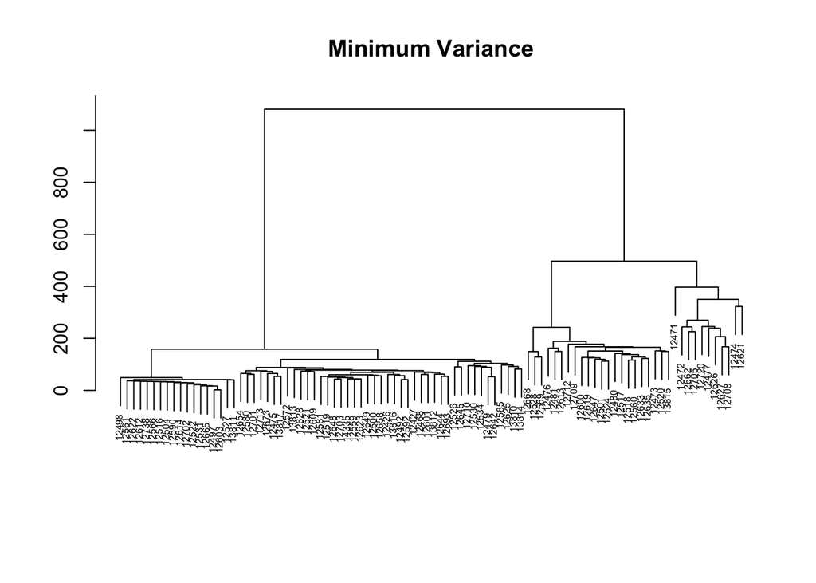

```r
plot(hiercFit, main="Minimum Variance", xlab="", ylab="", sub="", cex =.5)
```

Distance is Eclidean distance and clustering method is Ward’s minimum varience.

Based on the plot, it is good to split the cluster into two.

```r
cutree(hiercFit, k = 2)
```

```
## 12426 12427 12468 12471 12472 12473 12474 12475 12476 12477 12479 12480
##     1     1     1     2     2     2     2     1     2     2     1     2
## 12481 12492 12497 12498 12500 12501 12504 12516 12517 12518 12519 12520
##     2     1     1     1     1     2     1     1     2     2     1     2
## 12521 12522 12524 12526 12527 12528 12530 12531 12534 12559 12560 12561
##     1     1     2     1     1     2     1     1     1     1     2     1
## 12566 12569 12572 12580 12581 12585 12590 12592 12600 12601 12603 12609
##     1     2     1     1     1     1     1     1     2     1     1     1
## 12612 12613 12614 12619 12621 12622 12623 12625 12626 12627 12628 12633
##     1     2     1     2     2     1     1     1     2     2     1     2
## 12635 12642 12644 12645 12647 12648 12649 12654 12658 12662 12665 12668
##     2     1     1     1     2     1     1     1     1     2     1     2
## 12673 12693 12701 12702 12703 12705 12708 12709 12710 12712 12713 12720
##     1     1     1     1     1     2     2     2     1     2     1     2
## 12738 13810 13811 13812 13813 13814 13815 13816 13817 14335
##     1     1     1     1     1     1     2     1     1     1
```

```r
clustLabels <- cutree(hiercFit, k = 2)

hiercClust1 = Nazi [clustLabels == 1,]
hiercClust2 = Nazi[clustLabels == 2,]

hiercClust1 <- droplevels(hiercClust1)
hiercClust2 <- droplevels(hiercClust2)
```

### Clusters Analysis

```r
summary(hiercClust1)
```

```
##    InvoiceNo      StockCode                                 Description
##  555383 :  88   POST   : 233   POSTAGE                            : 233
##  540458 :  72   22326  :  63   ROUND SNACK BOXES SET OF4 WOODLAND :  63
##  575886 :  49   22328  :  42   ROUND SNACK BOXES SET OF 4 FRUITS  :  42
##  571328 :  46   22554  :  36   PLASTERS IN TIN WOODLAND ANIMALS   :  36
##  564856 :  44   22423  :  30   REGENCY CAKESTAND 3 TIER           :  30
##  571824 :  43   22556  :  29   PLASTERS IN TIN CIRCUS PARADE      :  29
##  (Other):4244   (Other):4153   (Other)                            :4153
##     Quantity              InvoiceDate     UnitPrice         CustomerID
##  Min.   : 1.000   2/6/11 15:13  :  88   Min.   :  0.190   12474  : 242
##  1st Qu.: 4.000   7/1/11 12:28  :  72   1st Qu.:  1.250   12621  : 227
##  Median : 8.000   11/11/11 13:57:  49   Median :  2.100   12517  : 184
##  Mean   : 7.804   17/10/11 11:27:  46   Mean   :  4.486   12471  : 181
##  3rd Qu.:12.000   31/8/11 9:11  :  44   3rd Qu.:  4.250   12472  : 181
##  Max.   :12.000   19/10/11 11:49:  43   Max.   :599.500   12705  : 169
##                   (Other)       :4244                     (Other):3402
##     Country
##  Germany:4586
##
##
##
##
##
##
```

```r
nlevels(hiercClust1$CustomerID)
```

```
## [1] 94
```

```r
nlevels(hiercClust1$StockCode)
```

```
## [1] 1184
```

```r
summary(hiercClust2)
```

```
##    InvoiceNo      StockCode                                 Description
##  555383 :  46   POST   : 139   POSTAGE                            : 139
##  540458 :  39   22326  :  31   ROUND SNACK BOXES SET OF4 WOODLAND :  31
##  564856 :  27   22328  :  23   ROUND SNACK BOXES SET OF 4 FRUITS  :  23
##  575886 :  27   22551  :  19   PLASTERS IN TIN SPACEBOY           :  19
##  560590 :  25   22554  :  18   PLASTERS IN TIN WOODLAND ANIMALS   :  18
##  571065 :  25   21731  :  16   RED TOADSTOOL LED NIGHT LIGHT      :  16
##  (Other):2296   (Other):2239   (Other)                            :2239
##     Quantity              InvoiceDate     UnitPrice         CustomerID
##  Min.   : 1.000   2/6/11 15:13  :  46   Min.   :  0.390   12621  : 121
##  1st Qu.: 4.000   7/1/11 12:28  :  39   1st Qu.:  1.450   12474  : 117
##  Median : 8.000   11/11/11 13:57:  27   Median :  2.100   12471  : 104
##  Mean   : 7.805   31/8/11 9:11  :  27   Mean   :  4.137   12720  : 102
##  3rd Qu.:12.000   13/10/11 14:59:  25   3rd Qu.:  4.250   12517  :  97
##  Max.   :12.000   19/7/11 15:55 :  25   Max.   :424.060   12472  :  96
##                   (Other)       :2296                     (Other):1848
##     Country
##  Germany:2485
##
##
##
##
##
##
```

```r
nlevels(hiercClust2$CustomerID)
```

```
## [1] 91
```

```r
nlevels(hiercClust2$StockCode)
```

```
## [1] 912
```

So, there are 91 unique customers which bought 912 unique products in this cluster. Total 2485 records are inside the cluster.

```r
summary(hiercClust1$Description,11)
```

```
##                             POSTAGE ROUND SNACK BOXES SET OF4 WOODLAND
##                                 233                                  63
##  ROUND SNACK BOXES SET OF 4 FRUITS     PLASTERS IN TIN WOODLAND ANIMALS
##                                  42                                  36
##            REGENCY CAKESTAND 3 TIER      PLASTERS IN TIN CIRCUS PARADE
##                                  30                                  29
##                 SPACEBOY LUNCH BOX           JUMBO BAG WOODLAND ANIMALS
##                                  27                                  25
##            PLASTERS IN TIN SPACEBOY              6 RIBBONS RUSTIC CHARM
##                                  24                                  23
##                             (Other)
##                                4054
```

```r
summary(hiercClust2$Description,11)
```

```
##                             POSTAGE ROUND SNACK BOXES SET OF4 WOODLAND
##                                 139                                  31
##  ROUND SNACK BOXES SET OF 4 FRUITS             PLASTERS IN TIN SPACEBOY
##                                  23                                  19
##    PLASTERS IN TIN WOODLAND ANIMALS       RED TOADSTOOL LED NIGHT LIGHT
##                                  18                                  16
##              6 RIBBONS RUSTIC CHARM             JUMBO BAG RED RETROSPOT
##                                  15                                  15
##      PLASTERS IN TIN CIRCUS PARADE           SET OF 3 REGENCY CAKE TINS
##                                  15                                  14
##                             (Other)
##                                2180
```

Top ten products of two clusters are similar to each other.

In both clusters, we can find three types of clusters, two types of round snack boxes set, one cake related product, one ribbon rustic charm, one type of jumbo bag. The only diffrence is one group has LED product and the other group has lunch box related product.

## Segmentation on the Whole Data

Clustering will be done on the whole data. Customer-Product matrix will be created first.

```r
retailmatrix <- xtabs(Quantity ~ CustomerID + StockCode, data = retailData, sparse = TRUE)
str(retailmatrix)
```

```
## Formal class 'dgCMatrix' [package "Matrix"] with 6 slots
##   ..@ i       : int [1:228872] 86 238 270 276 277 330 335 413 417 556 ...
##   ..@ p       : int [1:4071] 0 31 46 69 72 72 77 81 103 148 ...
##   ..@ Dim     : int [1:2] 4372 4070
##   ..@ Dimnames:List of 2
##   .. ..$ CustomerID: chr [1:4372] "12346" "12347" "12348" "12349" ...
##   .. ..$ StockCode : chr [1:4070] "10002" "10080" "10120" "10123C" ...
##   ..@ x       : num [1:228872] 12 12 1 12 24 1 1 8 10 1 ...
##   ..@ factors : list()
```

EM clustering will be used and distance is Euclidean distance.

```r
library(mclust)
emFit <- Mclust(retailData)
clustLabels <- emFit$classification
summary(emFit)
```

```
## ----------------------------------------------------
## Gaussian finite mixture model fitted by EM algorithm
## ----------------------------------------------------
##
## Mclust EEV (ellipsoidal, equal volume and shape) model with 9 components:
##
##  log-likelihood      n  df       BIC       ICL
##       -17020733 331960 340 -34045788 -34213634
##
## Clustering table:
##      1      2      3      4      5      6      7      8      9
##  10724  33961  49889  13469   1990   5270 110700 105881     76
```

9 different clusters are made.

```r
emClust1 = retailData[clustLabels == 1,]
emClust2 = retailData[clustLabels == 2,]
emClust3 = retailData[clustLabels == 3,]
emClust4 = retailData[clustLabels == 4,]
emClust5 = retailData[clustLabels == 5,]
emClust6 = retailData[clustLabels == 6,]
emClust7 = retailData[clustLabels == 7,]
emClust8 = retailData[clustLabels == 8,]
emClust9 = retailData[clustLabels == 9,]

emClust1 <- droplevels(emClust1)
emClust2 <- droplevels(emClust2)
emClust3 <- droplevels(emClust3)
emClust4 <- droplevels(emClust4)
emClust5 <- droplevels(emClust5)
emClust6 <- droplevels(emClust6)
emClust7 <- droplevels(emClust7)
emClust8 <- droplevels(emClust8)
emClust9 <- droplevels(emClust9)
```

### Clusters Analysis

Top-ten products which appears most in each cluster will be analysed.

```r
summary(emClust1,11)
```

```
##    InvoiceNo       StockCode                                 Description
##  562046 :   64   22554  : 150   PLASTERS IN TIN WOODLAND ANIMALS   : 150
##  570672 :   63   22556  : 140   PLASTERS IN TIN CIRCUS PARADE      : 140
##  565857 :   43   22629  : 130   SPACEBOY LUNCH BOX                 : 130
##  571328 :   42   22551  : 122   PLASTERS IN TIN SPACEBOY           : 122
##  574740 :   41   21731  : 111   RED TOADSTOOL LED NIGHT LIGHT      : 111
##  573362 :   38   22630  : 104   DOLLY GIRL LUNCH BOX               : 104
##  537201 :   37   21080  :  96   SET/20 RED RETROSPOT PAPER NAPKINS :  96
##  570467 :   34   22961  :  93   JAM MAKING SET PRINTED             :  93
##  579792 :   33   22555  :  85   PLASTERS IN TIN STRONGMAN          :  85
##  564372 :   32   22077  :  79   6 RIBBONS RUSTIC CHARM             :  79
##  (Other):10297   (Other):9614   (Other)                            :9614
##     Quantity             InvoiceDate      UnitPrice        CustomerID
##  Min.   : 6.00   2/8/11 10:34  :   64   Min.   : 0.120   14911  :1619
##  1st Qu.:12.00   11/10/11 14:52:   63   1st Qu.: 0.850   14156  : 204
##  Median :12.00   7/9/11 14:13  :   43   Median : 1.450   12681  : 200
##  Mean   :11.87   17/10/11 11:27:   42   Mean   : 1.942   12540  : 197
##  3rd Qu.:12.00   6/11/11 16:07 :   41   3rd Qu.: 1.950   12474  : 173
##  Max.   :12.00   30/10/11 13:06:   38   Max.   :28.000   12621  : 157
##                  5/12/10 14:19 :   37                    12471  : 155
##                  9/6/11 10:23  :   35                    12682  : 155
##                  10/10/11 16:06:   34                    12472  : 142
##                  25/3/11 12:04 :   33                    12683  : 132
##                  (Other)       :10294                    (Other):7590
##         Country
##  Germany    :2595
##  France     :2167
##  EIRE       :1876
##  Spain      : 581
##  Belgium    : 528
##  Switzerland: 489
##  Portugal   : 336
##  Norway     : 292
##  Italy      : 204
##  Netherlands: 202
##  (Other)    :1454
```

```r
nlevels(emClust1$CustomerID)
```

```
## [1] 384
```

```r
nlevels(emClust1$StockCode)
```

```
## [1] 1445
```

There are 384 unique customers which bought 1445 unique products in this cluster. Total 10724 records are inside the cluster. This group includes mostly people from other countries except UK. Plasters and Lunchboxes are most bought products in this clusters. We have seen that in Germany and France, plasters and lunchboxes are most bought products.

Apparently, this cluster represents the shopping pattern of people from other countries except UK.

```r
summary(emClust2,11)
```

```
##    InvoiceNo       StockCode                                Description
##  543040 :  198   22423  :  702   REGENCY CAKESTAND 3 TIER         :  702
##  547063 :  160   22720  :  333   SET OF 3 CAKE TINS PANTRY DESIGN :  333
##  547651 :  111   21754  :  311   HOME BUILDING BLOCK WORD         :  311
##  542107 :  109   21755  :  284   LOVE BUILDING BLOCK WORD         :  284
##  554098 :  102   82486  :  255   WOOD S/3 CABINET ANT WHITE FINISH:  255
##  547358 :   98   48194  :  242   DOORMAT HEARTS                   :  242
##  536796 :   91   82484  :  242   WOOD BLACK BOARD ANT WHITE FINISH:  242
##  547498 :   89   20685  :  238   DOORMAT RED RETROSPOT            :  238
##  541848 :   86   22776  :  235   SWEETHEART CAKESTAND 3 TIER      :  234
##  539988 :   85   48187  :  232   DOORMAT NEW ENGLAND              :  232
##  (Other):32832   (Other):30887   (Other)                          :30888
##     Quantity             InvoiceDate      UnitPrice        CustomerID
##  Min.   : 1.000   2/2/11 17:06 :  198   Min.   : 0.001   17841  :  616
##  1st Qu.: 1.000   20/3/11 13:33:  160   1st Qu.: 3.750   14606  :  500
##  Median : 2.000   24/3/11 12:11:  111   Median : 5.950   12748  :  300
##  Mean   : 2.056   25/1/11 13:38:  109   Mean   : 6.483   14527  :  281
##  3rd Qu.: 2.000   22/5/11 13:01:  102   3rd Qu.: 8.500   14769  :  273
##  Max.   :12.000   22/3/11 12:25:   98   Max.   :85.000   15039  :  264
##                   2/12/10 15:46:   91                    15311  :  247
##                   23/3/11 12:24:   89                    17337  :  244
##                   27/2/11 12:41:   87                    18118  :  240
##                   23/1/11 13:31:   86                    13263  :  185
##                   (Other)      :32830                    (Other):30811
##                  Country
##  Spain               :    5
##  Sweden              :    2
##  Switzerland         :   66
##  United Arab Emirates:    2
##  United Kingdom      :33878
##  Unspecified         :    6
##  USA                 :    2
##
##
##
##
```

```r
nlevels(emClust2$CustomerID)
```

```
## [1] 2250
```

```r
nlevels(emClust2$StockCode)
```

```
## [1] 2383
```

There are 2250 unique customers which bought 2383 unique products in this cluster. Total 33961 records are inside the cluster. Most of the customers in this cluster are from UK. In this cluster, there are two types of wood funitures, 2 types of baking product, three kinds of doormat, and two type of building block word.

```r
summary(emClust3,11)
```

```
##    InvoiceNo       StockCode                                Description
##  579196 :  353   22423  :  494   REGENCY CAKESTAND 3 TIER         :  494
##  578270 :  345   23355  :  417   HOT WATER BOTTLE KEEP CALM       :  417
##  567656 :  327   23356  :  363   LOVE HOT WATER BOTTLE            :  363
##  572552 :  300   22720  :  336   SET OF 3 CAKE TINS PANTRY DESIGN :  336
##  580727 :  227   22138  :  323   BAKING SET 9 PIECE RETROSPOT     :  323
##  572103 :  202   23284  :  313   DOORMAT KEEP CALM AND COME IN    :  313
##  576339 :  191   22112  :  298   CHOCOLATE HOT WATER BOTTLE       :  298
##  573576 :  148   22111  :  297   SCOTTIE DOG HOT WATER BOTTLE     :  297
##  578921 :  141   22624  :  280   IVORY KITCHEN SCALES             :  280
##  577504 :  136   22139  :  260   RETROSPOT TEA SET CERAMIC 11 PC  :  260
##  (Other):47519   (Other):46508   (Other)                          :46508
##     Quantity              InvoiceDate      UnitPrice         CustomerID
##  Min.   : 1.000   28/11/11 15:54:  353   Min.   :  0.001   14096  : 2427
##  1st Qu.: 1.000   23/11/11 13:39:  346   1st Qu.:  1.950   17841  : 1592
##  Median : 2.000   21/9/11 14:40 :  327   Median :  4.950   12748  : 1093
##  Mean   : 1.949   24/10/11 17:07:  300   Mean   :  5.331   16549  :  414
##  3rd Qu.: 2.000   5/12/11 17:17 :  227   3rd Qu.:  7.950   14606  :  397
##  Max.   :12.000   20/10/11 15:57:  202   Max.   :110.000   14527  :  286
##                   14/11/11 15:27:  191                     13521  :  271
##                   31/10/11 14:09:  148                     16360  :  269
##                   27/11/11 11:57:  141                     16910  :  258
##                   20/11/11 12:36:  136                     15993  :  246
##                   (Other)       :47518                     (Other):42636
##                  Country
##  Spain               :    2
##  Switzerland         :   27
##  United Arab Emirates:    3
##  United Kingdom      :49813
##  Unspecified         :   38
##  USA                 :    6
##
##
##
##
##
```

```r
nlevels(emClust3$CustomerID)
```

```
## [1] 2537
```

```r
nlevels(emClust3$StockCode)
```

```
## [1] 2604
```

This group represents one of the group of customers from UK.

```r
summary(emClust4,11)
```

```
##    InvoiceNo       StockCode
##  570672 :  112   22326  :  152
##  562046 :   97   22328  :  115
##  540458 :   70   22138  :  109
##  568095 :   65   23245  :  107
##  564734 :   63   20725  :  102
##  571034 :   49   85099B :  100
##  576927 :   48   20726  :   97
##  540550 :   46   20712  :   96
##  569866 :   45   22139  :   95
##  578541 :   45   22720  :   93
##  (Other):12829   (Other):12403
##                               Description       Quantity
##  ROUND SNACK BOXES SET OF4 WOODLAND :  152   Min.   : 1.000
##  ROUND SNACK BOXES SET OF 4 FRUITS  :  115   1st Qu.: 4.000
##  BAKING SET 9 PIECE RETROSPOT       :  109   Median : 6.000
##  SET OF 3 REGENCY CAKE TINS         :  107   Mean   : 6.417
##  LUNCH BAG RED RETROSPOT            :  102   3rd Qu.: 8.000
##  JUMBO BAG RED RETROSPOT            :  100   Max.   :11.000
##  LUNCH BAG WOODLAND                 :   97
##  JUMBO BAG WOODLAND ANIMALS         :   96
##  RETROSPOT TEA SET CERAMIC 11 PC    :   95
##  SET OF 3 CAKE TINS PANTRY DESIGN   :   93
##  (Other)                            :12403
##          InvoiceDate      UnitPrice       CustomerID
##  11/10/11 14:52:  112   Min.   :0.190   14911  :1886
##  2/8/11 10:34  :   97   1st Qu.:1.950   14156  : 329
##  7/1/11 12:28  :   70   Median :2.950   12681  : 220
##  23/9/11 14:49 :   65   Mean   :2.931   12567  : 219
##  28/8/11 13:32 :   63   3rd Qu.:3.750   12682  : 216
##  13/10/11 12:47:   49   Max.   :7.450   12484  : 163
##  17/11/11 11:02:   48                   12621  : 152
##  10/1/11 9:11  :   46                   12474  : 149
##  24/11/11 15:01:   45                   12720  : 143
##  6/10/11 14:50 :   45                   12362  : 140
##  (Other)       :12829                   (Other):9852
##             Country
##  Germany        :3105
##  France         :2908
##  EIRE           :2260
##  Spain          : 867
##  Belgium        : 852
##  Switzerland    : 529
##  Portugal       : 474
##  Italy          : 276
##  Australia      : 234
##  Channel Islands: 233
##  (Other)        :1731
```

```r
nlevels(emClust4$CustomerID)
```

```
## [1] 383
```

```r
nlevels(emClust4$StockCode)
```

```
## [1] 1330
```

There are 383 unique customers which bought 1330 unique products in this cluster. Total 13469 records are inside the cluster. This group is also another group representing customers from other countries except UK. In this cluster, there are various kinds of bag products and two types of round snack boxes set.

```r
summary(emClust5,11)
```

```
##    InvoiceNo      StockCode                                Description
##  569866 : 105   POST   : 264   POSTAGE                           : 264
##  553017 :  49   22423  :  42   REGENCY CAKESTAND 3 TIER          :  42
##  540469 :  46   22655  :  31   VINTAGE RED KITCHEN CABINET       :  31
##  559665 :  46   22826  :  29   LOVE SEAT ANTIQUE WHITE METAL     :  29
##  564734 :  42   20750  :  27   RED RETROSPOT MINI CASES          :  27
##  572065 :  37   22827  :  22   RUSTIC  SEVENTEEN DRAWER SIDEBOARD:  22
##  569870 :  35   21843  :  21   RED RETROSPOT CAKE STAND          :  21
##  557621 :  32   22847  :  18   BREAD BIN DINER STYLE IVORY       :  18
##  578488 :  29   C2     :  17   CARRIAGE                          :  17
##  542303 :  24   22625  :  15   RED KITCHEN SCALES                :  15
##  (Other):1545   (Other):1504   (Other)                           :1504
##     Quantity             InvoiceDate     UnitPrice        CustomerID
##  Min.   : 1.00   6/10/11 14:50 : 105   Min.   :  0.21   12757  : 192
##  1st Qu.: 2.00   12/5/11 19:01 :  49   1st Qu.:  4.95   12484  : 125
##  Median : 2.00   11/7/11 13:35 :  46   Median :  8.25   12556  :  83
##  Mean   : 3.02   7/1/11 14:04  :  46   Mean   : 21.26   12444  :  70
##  3rd Qu.: 4.00   28/8/11 13:32 :  42   3rd Qu.: 14.95   12502  :  60
##  Max.   :10.00   20/10/11 13:06:  37   Max.   :700.00   12540  :  56
##                  6/10/11 14:59 :  35                    12539  :  53
##                  21/6/11 14:00 :  32                    12766  :  42
##                  24/11/11 12:53:  29                    12597  :  37
##                  27/1/11 11:05 :  24                    12779  :  36
##                  (Other)       :1545                    (Other):1236
##            Country
##  Spain         :514
##  Portugal      :365
##  Germany       :206
##  Norway        :183
##  France        :167
##  United Kingdom:158
##  Switzerland   :126
##  Poland        : 73
##  Italy         : 51
##  Netherlands   : 29
##  (Other)       :118
```

```r
nlevels(emClust5$CustomerID)
```

```
## [1] 342
```

```r
nlevels(emClust5$StockCode)
```

```
## [1] 603
```

There are 342 unique customers which bought 603 unique products in this cluster. Total 1990 records are inside the cluster. This group is also another group in which most the customers are from other countries except UK. Most of the products in this cluster are funiture related products.

```r
summary(emClust6,11)
```

```
##    InvoiceNo      StockCode                        Description
##  555383 : 105   POST   : 738   POSTAGE                   : 738
##  562560 :  87   22423  : 145   REGENCY CAKESTAND 3 TIER  : 145
##  544074 :  76   C2     : 103   CARRIAGE                  : 103
##  577228 :  76   20750  :  90   RED RETROSPOT MINI CASES  :  90
##  569332 :  65   22624  :  84   IVORY KITCHEN SCALES      :  84
##  539050 :  60   22627  :  59   MINT KITCHEN SCALES       :  59
##  578541 :  53   22625  :  57   RED KITCHEN SCALES        :  57
##  557328 :  45   20749  :  55   ASSORTED COLOUR MINI CASES:  55
##  560491 :  44   21843  :  46   RED RETROSPOT CAKE STAND  :  46
##  575886 :  44   22846  :  43   BREAD BIN DINER STYLE RED :  43
##  (Other):4615   (Other):3850   (Other)                   :3850
##     Quantity             InvoiceDate     UnitPrice        CustomerID
##  Min.   :1.000   2/6/11 15:13  : 105   Min.   :  0.12   14911  : 931
##  1st Qu.:1.000   5/8/11 17:12  :  87   1st Qu.:  5.95   14156  : 284
##  Median :2.000   15/2/11 14:49 :  76   Median :  8.25   12517  : 154
##  Mean   :2.199   18/11/11 12:07:  76   Mean   : 10.50   14646  : 151
##  3rd Qu.:3.000   3/10/11 13:46 :  65   3rd Qu.: 12.75   17097  : 131
##  Max.   :7.000   15/12/10 16:21:  60   Max.   :350.00   12637  : 128
##                  24/11/11 15:01:  53                    12577  : 112
##                  20/6/11 9:53  :  45                    12681  :  90
##                  11/11/11 13:57:  44                    14277  :  89
##                  19/7/11 10:51 :  44                    12682  :  88
##                  (Other)       :4615                    (Other):3112
##             Country
##  France         :1316
##  EIRE           :1240
##  Germany        :1161
##  Belgium        : 293
##  Cyprus         : 217
##  Channel Islands: 181
##  Netherlands    : 178
##  Spain          : 131
##  Italy          : 114
##  Finland        : 102
##  (Other)        : 337
```

```r
nlevels(emClust6$CustomerID)
```

```
## [1] 296
```

```r
nlevels(emClust6$StockCode)
```

```
## [1] 1105
```

There are 296 unique customers which bought 1105 unique products in this cluster. Total 5270 records are inside the cluster. This group is also another group representing customers from other countries except UK. Most of the products in this cluster are kitchen related products.

```r
summary(emClust7,11)
```

```
##    InvoiceNo        StockCode
##  573576 :   279   85123A :   659
##  580727 :   271   85099B :   492
##  569246 :   216   20725  :   480
##  568346 :   208   22383  :   451
##  569897 :   199   20727  :   429
##  561894 :   171   22457  :   423
##  574481 :   165   22469  :   406
##  579196 :   155   22382  :   400
##  565541 :   144   21034  :   394
##  580956 :   142   20728  :   390
##  (Other):108750   (Other):106176
##                              Description        Quantity
##  WHITE HANGING HEART T-LIGHT HOLDER:   653   Min.   : 1.000
##  JUMBO BAG RED RETROSPOT           :   492   1st Qu.: 2.000
##  LUNCH BAG RED RETROSPOT           :   480   Median : 6.000
##  LUNCH BAG  BLACK SKULL.           :   429   Mean   : 6.068
##  NATURAL SLATE HEART CHALKBOARD    :   423   3rd Qu.:10.000
##  HEART OF WICKER SMALL             :   406   Max.   :12.000
##  LUNCH BAG SPACEBOY DESIGN         :   400
##  LUNCH BAG SUKI DESIGN             :   398
##  REX CASH+CARRY JUMBO SHOPPER      :   394
##  LUNCH BAG CARS BLUE               :   390
##  (Other)                           :106235
##          InvoiceDate       UnitPrice        CustomerID
##  31/10/11 14:09:   279   Min.   : 0.060   17841  :  2934
##  5/12/11 17:17 :   271   1st Qu.: 1.250   12748  :  1668
##  5/10/11 13:47 :   226   Median : 1.650   14096  :  1295
##  3/10/11 9:57  :   216   Mean   : 1.999   14606  :   879
##  26/9/11 15:28 :   208   3rd Qu.: 2.550   13263  :   674
##  6/10/11 16:01 :   199   Max.   :11.150   15719  :   587
##  31/7/11 15:00 :   171                    15311  :   571
##  4/11/11 12:45 :   165                    15005  :   533
##  28/11/11 15:54:   155                    14056  :   524
##  5/9/11 12:00  :   144                    13089  :   517
##  (Other)       :108666                    (Other):100518
##            Country
##  Switzerland   :    11
##  United Kingdom:110584
##  Unspecified   :   105
##
##
##
##
##
##
##
##
```

```r
nlevels(emClust7$CustomerID)
```

```
## [1] 2786
```

```r
nlevels(emClust7$StockCode)
```

```
## [1] 3013
```

There are 2786 unique customers which bought 3013 unique products in this cluster. Total 110700 records are inside the cluster. This is the largest cluster. This cluster inludes mostly customers from UK. There are seven kinds of bag including “REX CASH+CARRY JUMBO SHOPPER” and three types of fancy accessories in this cluster.

```r
summary(emClust8,10)
```

```
##    InvoiceNo        StockCode
##  576339 :   317   85123A :   695
##  575607 :   266   85099B :   475
##  567183 :   262   20725  :   465
##  570488 :   260   20727  :   440
##  571441 :   230   22457  :   422
##  566290 :   194   47566  :   386
##  556484 :   188   21034  :   384
##  562031 :   168   20728  :   381
##  554098 :   141   23203  :   376
##  (Other):103855   (Other):101857
##                              Description        Quantity
##  WHITE HANGING HEART T-LIGHT HOLDER:   695   Min.   : 1.000
##  JUMBO BAG RED RETROSPOT           :   475   1st Qu.: 2.000
##  LUNCH BAG RED RETROSPOT           :   465   Median : 6.000
##  LUNCH BAG  BLACK SKULL.           :   440   Mean   : 6.088
##  NATURAL SLATE HEART CHALKBOARD    :   422   3rd Qu.:10.000
##  PARTY BUNTING                     :   386   Max.   :12.000
##  REX CASH+CARRY JUMBO SHOPPER      :   384
##  LUNCH BAG CARS BLUE               :   381
##  LUNCH BAG SPACEBOY DESIGN         :   362
##  (Other)                           :101871
##          InvoiceDate       UnitPrice       CustomerID
##  14/11/11 15:27:   317   Min.   : 0.06   17841  : 2493
##  10/11/11 12:37:   266   1st Qu.: 1.25   14096  : 1216
##  10/10/11 17:12:   260   Median : 1.65   12748  : 1195
##  17/10/11 13:31:   230   Mean   : 2.04   14606  :  873
##  18/9/11 15:32 :   213   3rd Qu.: 2.95   15311  :  867
##  11/9/11 15:24 :   194   Max.   :11.15   14769  :  566
##  12/6/11 13:17 :   188                   13263  :  558
##  13/7/11 12:06 :   171                   15039  :  537
##  1/8/11 17:37  :   168                   13089  :  531
##  (Other)       :103874                   (Other):97045
##                  Country
##  Switzerland         :    13
##  United Arab Emirates:    31
##  United Kingdom      :105796
##  Unspecified         :    37
##  USA                 :     4
##
##
##
##
##
```

```r
nlevels(emClust8$CustomerID)
```

```
## [1] 2739
```

```r
nlevels(emClust8$StockCode)
```

```
## [1] 3006
```

There are 2739 unique customers which bought 3006 unique products in this cluster. Total 105881 records are inside the cluster. This is the second largest cluster. In fact, a lot of products in this clusters are similar to the previous cluster. This group also mostly includes customers from UK.

This cluster 7 and 8 should be combined to become one big cluster.

```r
summary(emClust9,10)
```

```
##    InvoiceNo    StockCode                              Description
##  545845 : 5   M      :36   Manual                            :36
##  557328 : 4   DOT    :12   DOTCOM POSTAGE                    :12
##  545332 : 3   22655  : 3   VINTAGE BLUE KITCHEN CABINET      : 3
##  548813 : 3   22656  : 3   VINTAGE RED KITCHEN CABINET       : 3
##  560710 : 3   22605  : 2   WOODEN CROQUET GARDEN SET         : 2
##  538095 : 2   22487  : 1   PINK METAL CHICKEN HEART          : 1
##  571751 : 2   22579  : 1   POSTAGE                           : 1
##  543253 : 1   22695  : 1   REGENCY TEA STRAINER              : 1
##  544578 : 1   22827  : 1   RUSTIC  SEVENTEEN DRAWER SIDEBOARD: 1
##  (Other):52   (Other):16   (Other)                           :16
##     Quantity             InvoiceDate   UnitPrice         CustomerID
##  Min.   :1.000   7/3/11 13:38  : 5   Min.   :   0.42   14096  :12
##  1st Qu.:1.000   20/6/11 9:53  : 4   1st Qu.:  14.95   14646  : 7
##  Median :1.000   1/3/11 15:52  : 3   Median : 394.84   12744  : 6
##  Mean   :1.066   20/7/11 12:51 : 3   Mean   : 881.03   12754  : 5
##  3rd Qu.:1.000   4/4/11 13:03  : 3   3rd Qu.:1241.98   12757  : 5
##  Max.   :3.000   19/10/11 11:18: 2   Max.   :8142.75   12352  : 3
##                  9/12/10 14:55 : 2                     12536  : 2
##                  1/3/11 16:53  : 1                     12748  : 2
##                  10/10/11 17:12: 1                     14911  : 2
##                  (Other)       :52                     (Other):32
##            Country
##  United Kingdom:31
##  Netherlands   : 9
##  Portugal      : 6
##  Singapore     : 6
##  Japan         : 5
##  Germany       : 4
##  France        : 3
##  Norway        : 3
##  Spain         : 3
##  (Other)       : 6
```

```r
nlevels(emClust9$CustomerID)
```

```
## [1] 40
```

```r
nlevels(emClust9$StockCode)
```

```
## [1] 25
```

This group has mixed group of customers.

### Final Conclusion on the clustering of whole data

Among 9 clusters, there are 4 clusters which represents the shopping pattern of customers from other countries except UK.

Various kinds of plasters, lunchboxes, round snack boxes sets, bag products, kitchen-related products, and funiture-related products are popular among those people.

There are 4 clusters which represents the shopping pattern of customers from UK.

Various kinds of bags, hot water bottles, doormats, baking products, wood funitures, fancy accessories, and building block word are popular among those people.

So, in order to improve Sale, the shop should consider bringing in variety of products related to the above categories.